# Scattering from Hard sphere and Lennard-Jones potentials

Using the tools from Lecture, study classical scattering from a hard sphere and from the Lennard-Jones potential. Plot typical trajectories, and compute and plot the differential scattering cross section for the hard-sphere and Lennard-Jones cases.

$$ \frac{d\sigma}{d\Omega} = \frac{b}{\sin(\theta)}\left| \frac{d\theta}{db} \right|^{-1} $$

Do this for two or three different values of the energy that you find most interesting. Study the phenomenon of orbiting in the Lennard-Jones case: what is the maximum number of orbits you can generate by carefully tuning the energy and impact parameter?

### We will use the scattering simulation in C++ via the python interface. The C++ does not need to be modified for this part.

### Swig it, compile it, add it to the path

```python
! swig -c++ -python swig/scattering.i
! python swig/setup.py build_ext --inplace
```

```
running build_ext
building '_scattering' extension
x86_64-linux-gnu-gcc -pthread -Wno-unused-result -Wsign-compare -DNDEBUG -g -fwrapv -O2 -Wall -g -fstack-protector-strong -Wformat -Werror=format-security -g -fwrapv -O2 -g -fstack-protector-strong -Wformat -Werror=format-security -Wdate-time -D_FORTIFY_SOURCE=2 -fPIC -I/usr/include/python3.7m -c sw…
x86_64-linux-gnu-g++ -pthread -shared -Wl,-O1 -Wl,-Bsymbolic-functions -Wl,-Bsymbolic-functions -Wl,-z,relro -Wl,-Bsymbolic-functions -Wl,-z,relro -g -fstack-protector-strong -Wformat -Werror=format-security -Wdate-time -D_FORTIFY_SOURCE=2 build/temp.linux-x86_64-3.7/swig/scattering_wrap.o -o /resul…
```

```python
import sys
import os
sys.path.append( os.path.abspath("swig") )
```

```python
import scattering
import numpy as np
import matplotlib.pyplot as plt
```

```python
params = {'legend.fontsize': 'large',
         'axes.labelsize': 'large',
         'axes.titlesize':'large',
         'xtick.labelsize':'large',
         'ytick.labelsize':'large'}
plt.rcParams.update(params)
```

## Simulation for Hard Sphere Scattering

### Plot the potential

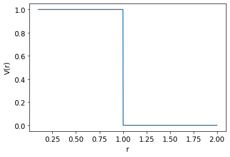

```python
E_min = 0.7
E_max = 1.0
n_E = 3
Evals = np.linspace(E_min, E_max, n_E+1)

b_min = 0.6
b_max = 2.0
n_b = 140
bvals = np.linspace(b_max, b_min, n_b+1)

V0 = 1.0
hs = scattering.hard_sphere_potential( V0 )

rvals = np.linspace(0.1,2.0,1000)
hsvals = [ hs(r) for r in rvals ]
plt.plot(rvals,hsvals)
plt.xlabel("r")
plt.ylabel("V(r)")
plt.show()
```

### Simulate the trajectory for several Energies

Here, I'm increasing $r_{max}$ to 20 to get a nice, long trajectory. I am also simulating 100,000 steps. This will smoothen out my distribution.

We also keep track of $\theta(b)$ in a separate array for convenience.

```python
E_theta_b_hs = np.zeros( shape=(n_E+1,n_b+1) )

for iE,E in enumerate(Evals):
    fig = plt.figure(iE+1)
    for ib,b in enumerate(bvals):
        xs = scattering.CrossSection_hard_sphere_potential( hs, E, b, 20.0, 100000 )
        deflection = xs.calculate_trajectory()
        traj = np.asarray( xs.get_trajectory() )
        E_theta_b_hs[iE,ib] = traj[-1,1]
        # Reduce the steps for plotting
        if ib % 10 == 0:
            x,y = traj[::1000,0] * np.cos( traj[::1000,1] ), traj[::1000,0] * np.sin(traj[::1000,1])
            plt.plot(x,y, label="%3.1f"%(b))
            plt.title("E = %2.0f"%(E))
            plt.xlabel("x")
            plt.ylabel("y")
            plt.legend()

plt.show()
```

[output not shown]

### Plot $\theta(b)$

We now use the extracted $\theta$ values along with the impact parameter to plot $\theta(b)$.

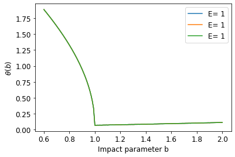

```python
for iE in np.arange(n_E) :
    plt.plot( bvals, E_theta_b_hs[iE,:], label="E=%2.0f" % (Evals[iE]))
plt.legend()
plt.xlabel("Impact parameter b")
plt.ylabel(r"$\theta(b)$")
```

Note that the slope above $r=1$ is small. This is expected! We don't have scattering in that region. We also see that all of the energies have the same cross section.

### Plot $d\theta / db$

Here, we now use the extracted values of $\theta(b)$ and numerically compute the derivative. You can choose any fixed-step method (so, not Ridder's). This is because there is a minimum step size. There are several ways to implement this, including just making a function that accepts the value of $x$ and returns the closest value. But, the simplest way is to just compute the derivative of the array itself.

For illustration I will use a binned five-point method. This is the same as the regular five-point method, but instead of a continuous function there is just an array.

```python
def derivative_fivepoint_binned( a, h) :
    dfdx = (a[:,0:-3] - 8*a[:,1:-2] + 8 * a[:,2:-1] - a[:,3:]) / (12*h)
    return dfdx
```

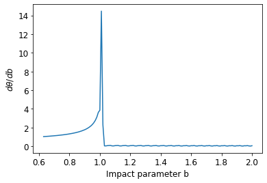

```python
db = (b_max - b_min) / n_b
dtheta_db_hs = derivative_fivepoint_binned(E_theta_b_hs[:,:], db)

plt.plot( bvals[:-3], np.abs(dtheta_db_hs[0,:]) )
plt.xlabel("Impact parameter b")
plt.ylabel(r"$d\theta/db$")
```

We see that the function is basically as expected. Above $r=1$, there are numerical precision issues but the function should be close to zero.

### Plot $d\sigma / d\Omega$

Let's try first to plot

$$ \frac{d\sigma}{d\Omega} = \frac{b}{\sin(\theta)} \left|\frac{d\theta}{db} \right|^{-1} $$

We'll do this only for one energy since the cross section is independent of energy for the hard sphere.

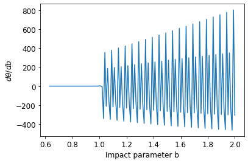

```python
dsigma_domega_hs = bvals[:-3] / np.sin(E_theta_b_hs[0,:-3])/ dtheta_db_hs[0,:]
plt.plot( bvals[:-3], dsigma_domega_hs )
plt.xlabel("Impact parameter b")
plt.ylabel(r"$d\theta / db$")
```

This obviously fails miserably, because we are dividing small numbers by small numbers, with some numerical fluctuations also! We therefore should only plot this for $r < 1.0$ because that is where it makes sense. Above that, the value is zero.

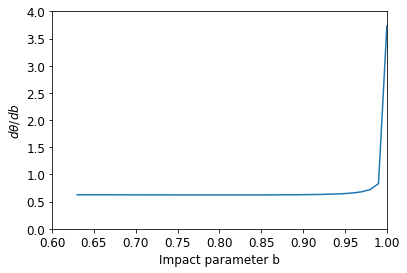

```python
plt.plot( bvals[:-3], dsigma_domega_hs )
plt.xlim(0.6,1)
plt.ylim(0,4)
plt.xlabel("Impact parameter b")
plt.ylabel(r"$d\theta / db$")
```

This is a much saner plot!

## Repeat for Lennard-Jones potential

### Plot the potential

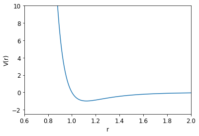

```python
E_min = 0.7
E_max = 0.8
n_E = 5
Evals = np.linspace(E_min, E_max, n_E+1)

b_min = 1.4
b_max = 2.0
n_b = 100
bvals = np.linspace(b_max, b_min, n_b+1)

lj = scattering.lennard_jones( V0 )


ljvals = [ lj(r) for r in rvals ]
plt.plot(rvals,ljvals)
plt.xlim(0.6,2.0)
plt.ylim(-2.5,10)
plt.xlabel("r")
plt.ylabel("V(r)")
plt.show()
```

### Simulate the trajectory

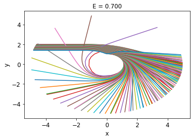

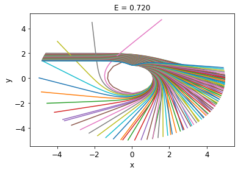

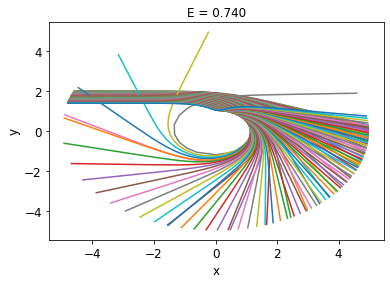

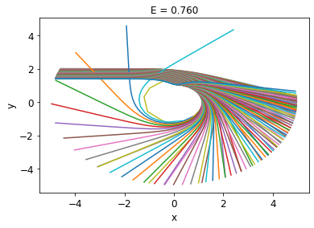

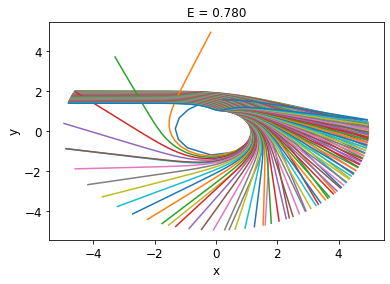

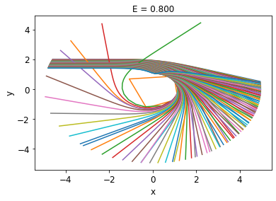

```python
E_theta_b_lj = np.zeros( shape=(n_E+1,n_b+1) )

for iE,E in enumerate(Evals):
    fig = plt.figure(iE+1)
    for ib,b in enumerate(bvals):
        xs = scattering.CrossSection_lennard_jones( lj, E, b, 5.0, 100000 )
        deflection = xs.calculate_trajectory()
        traj = np.asarray( xs.get_trajectory() )
        E_theta_b_lj[iE,ib] = traj[-1,1]
        # Reduce the steps for plotting
        x,y = traj[::1000,0] * np.cos( traj[::1000,1] ), traj[::1000,0] * np.sin(traj[::1000,1])
        plt.plot(x,y, label="%3.1f"%(b))
        plt.title("E = %4.3f"%(E))
        plt.xlabel("x")
        plt.ylabel("y")
```

## Plot $\theta(b)$

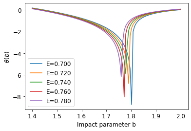

```python
for iE in np.arange(n_E) :
    plt.plot( bvals, E_theta_b_lj[iE,:],label="E=%4.3f" %(Evals[iE]) )
plt.xlabel("Impact parameter b")
plt.ylabel(r"$\theta(b)$")
plt.legend()
```

## Plot $d\theta/db$

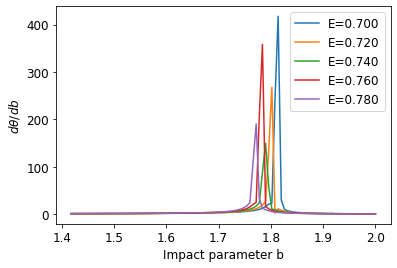

```python
dtheta_db_lj = derivative_fivepoint_binned(E_theta_b_lj[:,:], db)

for iE in np.arange(n_E) :
    plt.plot( bvals[:-3], np.abs(dtheta_db_lj[iE,:]),label="E=%4.3f" %(Evals[iE]) )
plt.xlabel("Impact parameter b")
plt.ylabel(r"$d\theta/db$")
plt.legend()
```

## Plot $d\sigma / d\Omega$

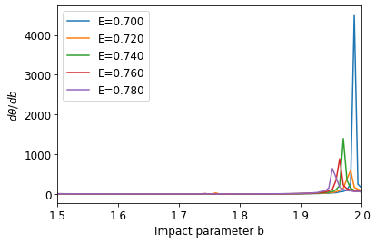

```python
dsigma_domega_lj = bvals[:-3] / np.abs(np.sin(E_theta_b_lj[:,:-3]))/ np.abs(dtheta_db_lj[:,:])
for iE in np.arange(n_E) :
    plt.plot( bvals[:-3], dsigma_domega_lj[iE],label="E=%4.3f" %(Evals[iE])  )
plt.xlabel("Impact parameter b")
plt.ylabel(r"$d\theta / db$")
plt.xlim(1.5,2)
plt.legend()
```

# Orbiting

To achieve orbiting, it is necessary to maximize the effective potential:

$$ U_{\mathrm{eff}}(r) = V(r) + \frac{Eb^2}{r^2} $$

So first we plot this for a few values of $E$ and $b$:

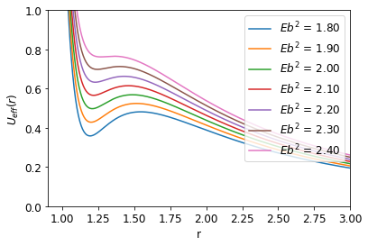

```python
rvals1 = np.linspace(0.1,5.0,1000)
centrifugal_vals = 1 / rvals1**2
ljvals1 = [ lj(r) for r in rvals1 ]


for eb2 in [1.8,1.9,2.0,2.1,2.2,2.3,2.4]:
    plt.plot(rvals1,ljvals1 + eb2 * centrifugal_vals, label=r"$Eb^2$ = %2.2f"%(eb2))
plt.xlim(0.9,3.0)
plt.ylim(0,1)
plt.xlabel("r")
plt.ylabel(r"$U_{eff}(r)$")
plt.legend(loc='upper right')
plt.show()
```

Right around $Eb^2 = 2.30$, the curve is turning over so that the local minimum and maximum merge into a local saddle. At this point, the energy of the incoming particle is around equal to the effective potential at that point. So we see that if $E \sim 0.705$ and $b=1.8$, we can maxize our orbits. We can play around a bit to find a nice optimum with many orbits at $E = 0.70542$.

```python
xs = scattering.CrossSection_lennard_jones( lj, 0.70542, 1.8, 5.0, 100000 )
deflection = xs.calculate_trajectory()
traj = np.asarray( xs.get_trajectory() )
```

```python
x,y = traj[:,0] * np.cos( traj[:,1] ), traj[:,0] * np.sin(traj[:,1])
```

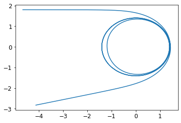

```python
plt.plot(x,y)
```

## Lots of orbiting!

You can see a fairly nice orbit here, corresponding to classical "resonances" of the Lennard-Jones potential.

This has quantum-mechanical analogues with $s$-wave scattering and other places.